# SI241 Stochastic Processes: Final Project

### (30pt) Problem 1: Simulation of M/M/1-Queue

Suppose that the arrival rate is $\lambda$ = 2jobs/min. Adjust the service rate $\mu$ as needed to create the the following three kinds of traffic intensity $\rho= \lambda/\mu:\rho = 0.4, 0.8, 1$. Run your simulation under each scenario for a long time to measure

1. [x] the mean and variance of the number of jobs in the system// ?
2. [X] the mean response time of jobs in the system
3. [X] the mean queueing time of jobs in the system

Then compare your results with theoretic results on the above performance metrics. What is more, check whether little’s law hold for all three scenarios.

#### Answer:

##### Analysis:

1. Since the rate that the process jump from state $S_i$ to $S_{i+1}$ is same as that of $S_{i+1}$ to $S_i$. So $\lambda p_i = \mu p_{i+1}$ for $i \ge 0$.
2. Server utilization – fraction of time server was busy = λ / μ
3. Average time spent by customers waiting in queue = ρ / (μ - λ)
4. Average time spent by customers in obtaining service (time spent waiting in queue + time spent get service from server) = 1 / (μ - λ)
5. Average length of queue = p * ρ / (1 - ρ)
6. Average number of customer inside the system (being serviced or waiting in queue) = ρ / (1 - ρ)
7. Variance of customer inside the system (being serviced or waiting in queue) = ρ / (1 - ρ) / (1 - ρ)

##### Simulation

First setup default values:

```r
MM1Simulation <- function(lambda = 2, rho = 1, print_every=2000, time = 5000, verbos = FALSE){
  digi <- 5
  mu <- lambda/rho
  simu_info <- paste("Arrival rate (lambda):",lambda,
                     "jobs/min,\nServer using rate (rho):",rho,
                     ",\nService rate (mu):",mu,
                     "jobs/min.\nSimulation time:",time,"min")
  out_log <- (" ========================== Setup ========================\n")
  out_log <- paste(out_log, simu_info,"\n")
  service_end_time <- -1
  i = 0
  total_wait <- 0
  total_time <- 0
  num_clients <- 0
  num_jobs <- rep(0, time)
  out_log = paste(out_log,"======================Begin Simulation==================\n")
  while ( i < time ){
    num_clients <- num_clients + 1
    if (i == 0 ){
      arrival_time <- round(x = rexp(1, lambda), digits = digi)
      start_time <- arrival_time
    }else{
      arrival_time = arrival_time + round(x = rexp(1, lambda), digits = digi)
      start_time <- max(arrival_time, service_end_time)
    }
    wait <-  start_time - arrival_time
    total_wait <- total_wait + wait
    service_time <- round(x = rexp(1,mu),digits = digi)
    # create clients
    total_time <- total_time + wait + service_time
    service_end_time <- service_time + start_time
    # add up the clients
    jStart = ceiling(arrival_time)
    jEnd = floor(service_end_time)
    if (jEnd >= jStart){
      for (j in seq(ceiling(arrival_time), floor(service_end_time))){
        num_jobs[j] <- num_jobs[j] + 1
      }
    }
    # output log
    i <- arrival_time
    if ( num_clients %% print_every == 0){
      log <- paste("arrival:", format(arrival_time, nsmall = digi),
                   "service:", format(service_time, nsmall = digi),
                   "start time:", format(start_time, nsmall = digi),
                   "end time:", format(service_end_time, nsmall = digi),
                   "wait:", format(wait, nsmall = digi))
      out_log <- paste(out_log, log, "\n")
    }
  }
  num_jobs <- num_jobs[1:time]
  out_log <- paste(out_log,"==========================Summary=======================\n")
  true <- paste("idealwait:",round(rho/(mu-lambda),digits = digi),",idealresp:",round(1/(mu-lambda),digits = digi))
  concl <- paste("mean wait:",round(total_wait/num_clients,digits = digi),",mean resp:",round(total_time/num_clients,digits = digi))
  out_log <- paste(out_log,true,"\n",concl,"\n",
                   "total clients:",num_clients,"\n",
                   "ideal mean of people in system:",round(rho/(1-rho),digits = digi),"\n",
                   "simulation of people in system:",round(mean(num_jobs),digits = digi),"\n",
                   "ideal variance of people in system:",round(rho /(1-rho)^2,digits = digi),"\n",
                   "simulation var of people in system:",round(var(num_jobs),digits = digi))
  if(verbos){
    cat(out_log)
  }
  return(num_jobs)
}
out <- MM1Simulation(lambda = 2, rho = 0.4, verbos = TRUE)
```

```
 ========================== Setup ========================
 Arrival rate (lambda): 2 jobs/min,
Server using rate (rho): 0.4 ,
Service rate (mu): 5 jobs/min.
Simulation time: 5000 min
 ======================Begin Simulation==================
 arrival: 1017.04363 service: 0.06281 start time: 1017.04363 end time: 1017.10644 wait: 0.00000
 arrival: 2011.75792 service: 0.30961 start time: 2011.81926 end time: 2012.12887 wait: 0.06134
 arrival: 3027.03926 service: 0.58014 start time: 3027.06343 end time: 3027.64357 wait: 0.02417
 arrival: 4034.18985 service: 0.01105 start time: 4034.21620 end time: 4034.22725 wait: 0.02635
 ==========================Summary=======================
 idealwait: 0.13333 ,idealresp: 0.33333
 mean wait: 0.12628 ,mean resp: 0.32507
 total clients: 9921
 ideal mean of people in system: 0.66667
 simulation of people in system: 0.6426
 ideal variance of people in system: 1.11111
 simulation var of people in system: 1.02347
```

### Visualization the outcomes

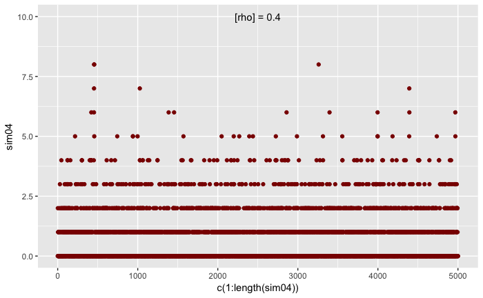

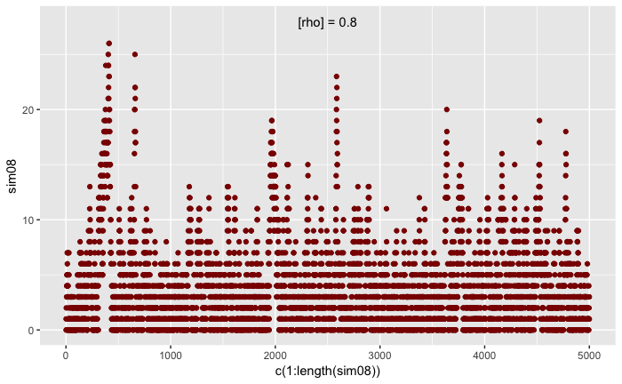

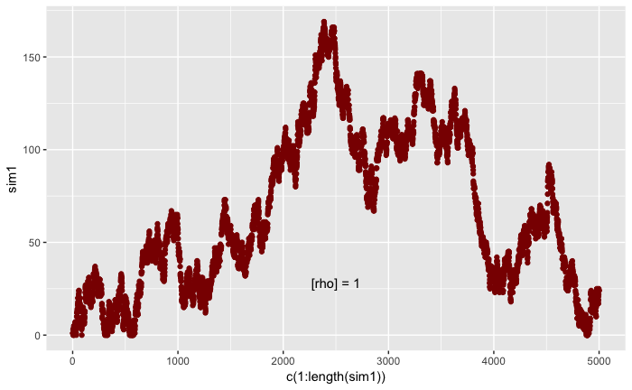